# R Notebook

Another reason for at least considering programs whose growth rates are as low as possible is that the growth rate ultimately determines how big a problem we can solve on a computer. Put another way, as computers get faster, our desire to solve larger problems on them continues to increase.

Suppose we can afford 1000 seconds, or about 17 minutes, to solve a given problem. How large a problem can we solve?

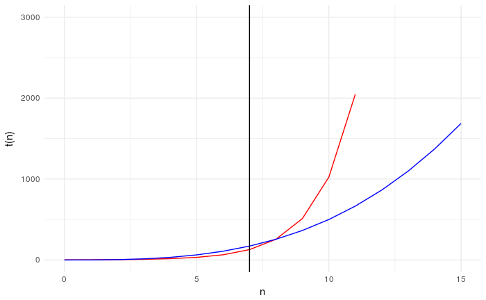

Suppose that we now buy a machine that runs ten times faster at no additional cost. Then for the same cost we can spend $10^4$ seconds on a problem where we spent $10^3$ seconds before.

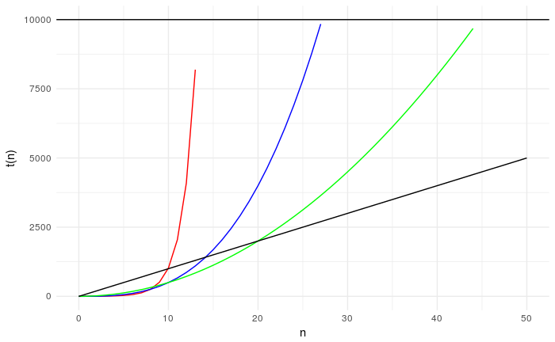

```python
def bubbleSort(alist):
    for passnum in range(len(alist)-1,0,-1):
        for i in range(passnum):
            if alist[i]>alist[i+1]:
                temp = alist[i]
                alist[i] = alist[i+1]
                alist[i+1] = temp

alist = [54,26,93,17,77,31,44,55,20]
bubbleSort(alist)
print alist
```

[output not shown]

```python
def bubbleSort(alist):
    for passnum in range(len(alist)-1,0,-1):
        for i in range(passnum):
            if alist[i]>alist[i+1]:
                temp = alist[i]
                alist[i] = alist[i+1]
                alist[i+1] = temp

alist = [54,26,93,17,77,31,44,55,20]
bubbleSort(alist)
print alist
```

```
[17, 20, 26, 31, 44, 54, 55, 77, 93]
```

```r
import time
def sumOfN(n):
   theSum = 0
   start = time.time()

   for i in range(1,n+1):
       theSum = theSum + i
   end = time.time()
   return theSum

def sumOfN2(n):
 start = time.time()
 res=(n*(n+1))/2
 end = time.time()
 return(end-start)


for n in range(0,8):
    print(n,sumOfN2(10**n))
```

```
(0, 9.5367431640625e-07)
(1, 9.5367431640625e-07)
(2, 9.5367431640625e-07)
(3, 1.1920928955078125e-06)
(4, 0.0)
(5, 9.5367431640625e-07)
(6, 9.5367431640625e-07)
(7, 0.0)
```